# Final_Codes_And_Results_Abdur_Rahman_Mahbub

|  | movieId | imdbId | tmdbId |
| --- | --- | --- | --- |
| count | 9742.000000 | 9.742000e+03 | 9734.000000 |
| mean | 42200.353623 | 6.771839e+05 | 55162.123793 |
| std | 52160.494854 | 1.107228e+06 | 93653.481487 |
| min | 1.000000 | 4.170000e+02 | 2.000000 |
| 25% | 3248.250000 | 9.518075e+04 | 9665.500000 |
| 50% | 7300.000000 | 1.672605e+05 | 16529.000000 |
| 75% | 76232.000000 | 8.055685e+05 | 44205.750000 |
| max | 193609.000000 | 8.391976e+06 | 525662.000000 |

Distributions

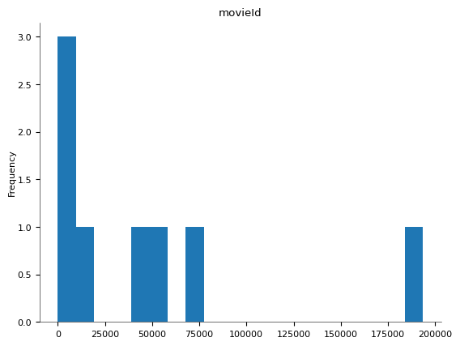

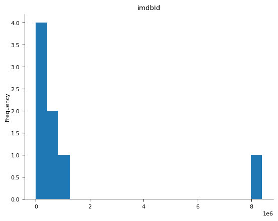

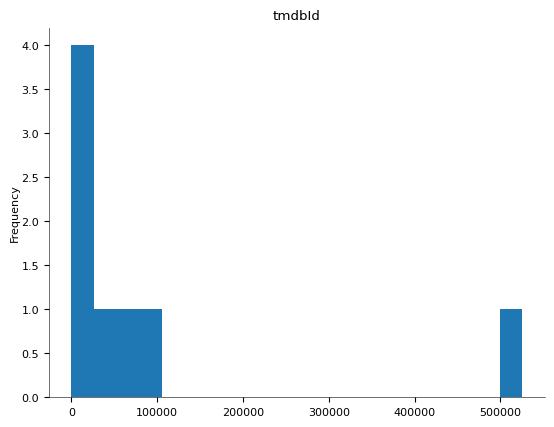

2-d distributions

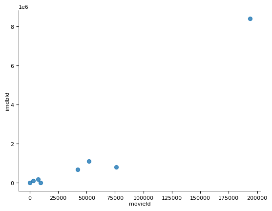

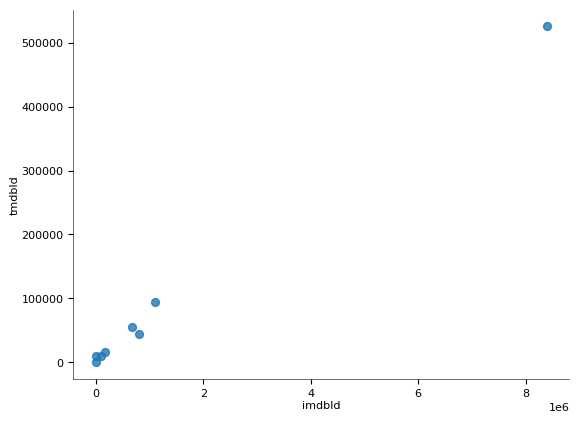

Values

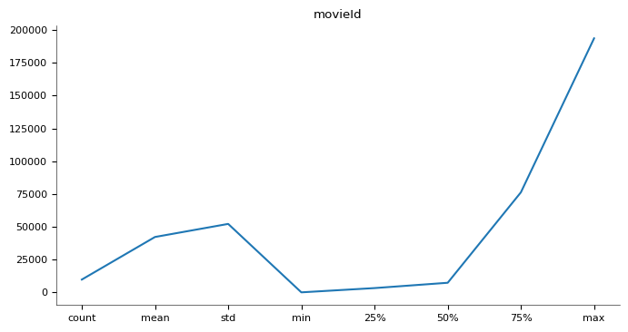

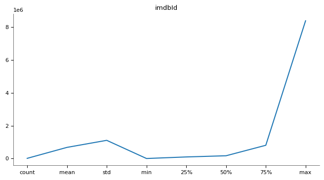

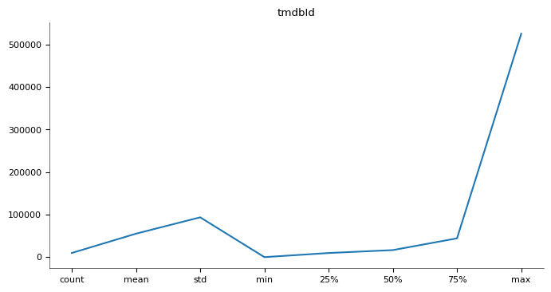

```python
# Descriptive Statistics for links_df dataset
links_df.describe()
```

In the next step, data will be merged and cleaned for research ease. It will be then modified and combined before splitted into training and test sets. User item matrix will be created and finally the matrix will be converted into sparse for further processing.

```python
# Merging 'tags' with 'movies' dataframe.
movies_df = pd.merge(movies_df, tags_df, on='movieId', how='left')

# Merging 'links'with 'movies' dataframe.
movies_df = pd.merge(movies_df, links_df, on='movieId', how='left')

# Cleaning NaN values in relevant columns.
movies_df['tag'] = movies_df['tag'].fillna('')

# Modifying 'genres' column in the new dataframe and combining all information for movie feature.
movies_df['genres'] = movies_df['genres'].str.replace('|', ' ')
movies_df['features'] = movies_df['genres'] + ' ' + movies_df['tag']

# Splitting data into training and test sets.
train_data, test_data = train_test_split(ratings_df, test_size=0.2, random_state=42)

# Creating user-item matrix and converting the dataframe into sparse
train_user_item_mtx = train_data.pivot_table(index='userId', columns='movieId', values='rating').fillna(0)
train_user_item_mtx_sp = csr_matrix(train_user_item_mtx.values)
```

**DEVELOPING RECOMMENDER SYSTEM USING COLLABORATIVE FILTERING METHOD**

We will now develop a recommender system base using collaborative filtering step by step. In the following step, matrix factorization will be performed using SVD method to eventually construct a matrix to predict suitable ratings for items that users have not rated yet.

Primarily, we will create a predicted rating matrix as 'ratings_predict' which will be used to generate user recommendations in the collaborative filtering. This matrix contains estimated ratings of the used dataframe.

For the collaborative filtering model, we will create a function as 'collaborative_filtering' to generate user specific movie recommendations.

```python
# Matrix Factorization using SVD method
num_factors = 50
U, sigma, Vt = svds(train_user_item_mtx_sp, k=num_factors)
sigma = np.diag(sigma)
ratings_predict = np.dot(np.dot(U, sigma), Vt)
```

```python
# Developing function for collaborative filtering
def collaborative_filtering(user_id, ratings_predict, num_recommendations=10):
    if user_id not in range(len(ratings_predict)):
        return []

    viewer_ratings = ratings_predict[user_id - 1]
    sorted_ratings = viewer_ratings.argsort()[::-1]
    viewed_movies = train_user_item_mtx.columns[train_user_item_mtx.loc[user_id].gt(0)].tolist()

    recommended_movies = []
    for idx in sorted_ratings:
        movie_id = idx + 1
        if movie_id not in viewed_movies:
            movie_info = movies_df[movies_df['movieId'] == movie_id]['title'].values
            if len(movie_info) > 0:
                movie_title = movie_info[0]
                recommended_movies.append((movie_title, viewer_ratings[idx]))
                if len(recommended_movies) >= num_recommendations:
                    break

    return recommended_movies
```

In this step, we will showcase an example of collaborative filtering recommendations. Let's assume a particular user as 'User 22'. The following example will show recommended movies for User 22 based on collaborative filtering technique, including titles and predicted ratings.

```python
userid_colfil = 22
colfil_recommended_movies = collaborative_filtering(userid_colfil, ratings_predict)
print(f"Recommendations for User {userid_colfil} Based on Collaborative Filtering")
for idx, (movie, rating) in enumerate(colfil_recommended_movies, start=1):
    print(f"{idx}. {movie}, {rating} ")
```

```
Recommendations for User 22 Based on Collaborative Filtering
1. Mary Shelley's Frankenstein (Frankenstein) (1994), 2.9500817570699662
2. Three Colors: White (Trzy kolory: Bialy) (1994), 2.661409823100069
3. Henry: Portrait of a Serial Killer (1986), 2.437057835556243
4. Hot Chick, The (2002), 2.2892239865760042
5. Kansas City (1996), 1.919819079163343
6. Wildcats (1986), 1.8998676689345166
7. Death Wish (1974), 1.6741195440440786
8. Men of Honor (2000), 1.6651515418966436
9. 15 Minutes (2001), 1.6415064369515318
10. Heidi (1937), 1.5689542766815503
```

**EVALUATING COLLABORATIVE FILTERING RECOMMENDATIONS**

In order to evaluate the performance of collaborative Filtering recommendations, we will calculate the Root Mean Square Error (RMSE) and Mean Absolute Error (MAE) by comparing predicted ratings against actual ratings in the test dataset. The lower the value of RMSE and MAE, means that the methods have better performed.

```python
# Make predictions and evaluate
predicted_test_ratings = []
for user_id, movie_id, rating in test_data[['userId', 'movieId', 'rating']].values:

    if user_id in ratings_predict and movie_id in ratings_predict[user_id]:
        predicted_ratings = ratings_predict[user_id][movie_id]
        predicted_test_ratings.append(predicted_ratings)
    else:
        ratings_mean = ratings_df['rating'].mean()
        predicted_test_ratings.append(ratings_mean)

test_ratings = test_data['rating'].values

# Calculating Root Mean Square Error (RMSE) of Collaborative Filtering
rmse_colfil = mean_squared_error(test_ratings, predicted_test_ratings, squared=False)
print(f"Root Mean Square Error (RMSE) of Collaborative Filtering: {rmse_colfil}")

# Calculating Mean Absolute Error (MAE) of Collaborative Filtering
mae_colfil = mean_absolute_error(test_ratings, predicted_test_ratings,)
print(f"Mean Absolute Error (MAE) of Collaborative Filtering: {mae_colfil}")
```

```
Root Mean Square Error (RMSE) of Collaborative Filtering: 1.0488361768130714
Mean Absolute Error (MAE) of Collaborative Filtering: 0.8315511597145444
```

**DEVELOPING RECOMMENDER SYSTEM USING CONTENT-BASED FILTERING METHOD**

In this section, we will develop content-based recommendations for movies. Initially, we try develop a matrix to segregate movies based on features using cosine similarity. Additionally, it will identify movies with similar genres and tags and will list them with individual ID’s. TfidfVectorizer is used to execute similarity matrix fiding similar item lists.

A new function will be generated for content-based filtering to identify similar movie indexes in the dataset. It will find movies with similar scores and content and will list it.

```python
# Executing similarity matrix
tfidf_vec = TfidfVectorizer(stop_words='english')
tfidf_matrix = tfidf_vec.fit_transform(movies_df['features'].values.astype('U'))
item_similar = cosine_similarity(tfidf_matrix, tfidf_matrix)
```

```python
# Developing function for content-based filtering
def content_based_filtering(movie_title, similarity_matrix, num_recommendations=10):
    movie_index = movies_df[movies_df['title'] == movie_title].index.values[0]
    similar_scores = similarity_matrix[movie_index]
    similar_movies_content = similar_scores.argsort()[::-1][1:]
    similar_movies = movies_df.iloc[similar_movies_content]
    return similar_movies[['title', 'genres', 'imdbId']]
```

The following codes to generate content-based recommendations for a particular movie. Let’s select 'Toy Story (1995)' as the selected movie, the function will generate recommendations of movies listed based on title, genres and similar content with this movie.

```python
movie_content_title = 'Toy Story (1995)'
content_based_recommended_movies = content_based_filtering(movie_content_title, item_similar)
print("\nRecommendations Based on Content-Based Filtering")
print(content_based_recommended_movies.head(10))
```

```
Recommendations Based on Content-Based Filtering
                                                   title  \
1                                       Toy Story (1995)
3214                                  Toy Story 2 (1999)
3217                                  Toy Story 2 (1999)
2484                                Bug's Life, A (1998)
8672                                           Up (2009)
4633                               Monsters, Inc. (2001)
11499                                       Moana (2016)
3966                    Emperor's New Groove, The (2000)
9544   Asterix and the Vikings (Astérix et les Viking...
10948                           The Good Dinosaur (2015)

                                            genres   imdbId
1      Adventure Animation Children Comedy Fantasy   114709
3214   Adventure Animation Children Comedy Fantasy   120363
3217   Adventure Animation Children Comedy Fantasy   120363
2484           Adventure Animation Children Comedy   120623
8672            Adventure Animation Children Drama  1049413
4633   Adventure Animation Children Comedy Fantasy   198781
11499  Adventure Animation Children Comedy Fantasy  3521164
3966   Adventure Animation Children Comedy Fantasy   120917
9544   Adventure Animation Children Comedy Fantasy   371552
10948  Adventure Animation Children Comedy Fantasy  1979388
```

**EVALUATING CONTENT-BASED FILTERING RECOMMENDATIONS**

```python
# Creating a small test dataset with 1000 ratings
num_ratings = 1000
test_data = ratings_df.sample(n=num_ratings, random_state=42)

# Developing function, predicted ratings and actual ratings
def predict_movie_ratings(test_data, similarity_matrix):
    predicted_ratings = []
    for user_id, movie_id, rating in test_data[['userId', 'movieId', 'rating']].values:
        recommended_movies = content_based_filtering(movies_df[movies_df['movieId'] == movie_id]['title'].values[0], similarity_matrix)
        predicted_rating = np.random.uniform(1, 5)
        predicted_ratings.append(predicted_rating)
    return predicted_ratings

predicted_ratings_test_content = predict_movie_ratings(test_data, item_similar)
test_ratings = test_data['rating'].values

# Calculate RMSE for content-based filtering
rmse_confil = mean_squared_error(test_ratings, predicted_ratings_test_content, squared=False)
print(f"Root Mean Square Error (RMSE) of Content-Based Filtering: {rmse_confil}")

# Calculate MAE for content-based filtering
mae_confil = mean_absolute_error(test_ratings, predicted_ratings_test_content,)
print(f"Mean Absolute Error (MAE) of Content-Based Filtering: {mae_confil}")
```

```
Root Mean Square Error (RMSE) of Content-Based Filtering: 1.666247359962544
Mean Absolute Error (MAE) of Content-Based Filtering: 1.3642609384041544
```

**DEVELOPING HYBRID RECOMMENDER SYSTEM USING COLLABORATIVE FILTERING & CONTENT-BASED FILTERING**

In this step, we will create a new function to combine collaborative and content-based recommendations method to generate more accurate and relevant suggestions to specific users and a particular movie.

```python
# Developing function for hybrid recommendations
def hybrid_recommendations_csp(user_id, movie_title, num_recommendations=10):

    if user_id not in train_user_item_mtx.index: # new users
        return content_based_filtering(movie_title, item_similar, num_recommendations)

    recommend_colfil = collaborative_filtering(user_id, ratings_predict, num_recommendations)
    recommend_confil = content_based_filtering(movie_title, item_similar, num_recommendations)

    hybrid_recommendations = []
    colfil_titles = [title for title, _ in recommend_colfil]
    for idx, (title, _) in enumerate(recommend_colfil):
        if title not in colfil_titles:
            hybrid_recommendations.append((title, idx+1))

    confil_titles = [title for title in recommend_confil['title']]
    for title in confil_titles:
        if title not in colfil_titles:
            hybrid_recommendations.append((title, idx+1))

    hybrid_recommendations = sorted(hybrid_recommendations, key=lambda x: x[1])
    return [movie[0] for movie in hybrid_recommendations[:num_recommendations]]
```

```python
hybrid_user_id = 22
movie_title_content = 'Toy Story (1995)'
hybrid_recommended_movies_csp = hybrid_recommendations_csp(hybrid_user_id, movie_title_content)
print(f"\nHybrid Recommendations for User {hybrid_user_id} based on '{movie_title_content}':")
for idx, movie in enumerate(hybrid_recommended_movies_csp, start=1):
    print(f"{idx}. {movie}")
    print(f"{idx}. {movie}")
```

```
Hybrid Recommendations for User 22 based on 'Toy Story (1995)':
1. Toy Story (1995)
1. Toy Story (1995)
2. Toy Story 2 (1999)
2. Toy Story 2 (1999)
3. Toy Story 2 (1999)
3. Toy Story 2 (1999)
4. Bug's Life, A (1998)
4. Bug's Life, A (1998)
5. Up (2009)
5. Up (2009)
6. Monsters, Inc. (2001)
6. Monsters, Inc. (2001)
7. Moana (2016)
7. Moana (2016)
8. Emperor's New Groove, The (2000)
8. Emperor's New Groove, The (2000)
9. Asterix and the Vikings (Astérix et les Vikings) (2006)
9. Asterix and the Vikings (Astérix et les Vikings) (2006)
10. The Good Dinosaur (2015)
10. The Good Dinosaur (2015)
```

**EVALUATING HYBRID RECOMMENDATION METHOD**

In this step, a function will be developed to utilize both collaborative and content-based filtering approaches to create a list of movies with similar titles, genres and content at the same time. Using predicted ratings and comparing with test ratings, RMSE and MAE is also calculated.

```python
# Creating functions & prediction for hybrid model evaluation
def evaluate_hybrid_recommendation(train_data, test_data):
    collaborative_predictions = collaborative_filtering(train_data, test_data)
    content_predictions = content_based_filtering(train_data, test_data)
    hybrid_predictions = hybrid_recommended_movies_csp(train_data, test_data)
```

```python
def predict_ratings_hybrid(test_data, train_user_item_matrix, ratings_predict, item_similar):
    predicted_ratings_hybrid_recomm = []

    for user_id, movie_id, _ in test_data[['userId', 'movieId', 'rating']].values:
        if user_id not in ratings_predict or movie_id not in ratings_predict[user_id]:
            predicted_rating = np.random.uniform(1, 5)
        else:
            predicted_rating = ratings_predict[user_id][movie_id]

        predicted_ratings_hybrid_recomm.append(predicted_rating)

    return predicted_ratings_hybrid_recomm


predicted_test_ratings_hybrid = predict_ratings_hybrid(test_data, train_user_item_mtx, ratings_predict, item_similar)

# Calculating RMSE of Hybrid Recommendations
rmse_hybrid_recomm = mean_squared_error(test_ratings, predicted_test_ratings_hybrid, squared=False)
print(f"Root Mean Square Error (RMSE) of Hybrid Recommendation: {rmse_hybrid_recomm}")

# Calculating MAE of Hybrid Recommendations
mae_hybrid_recomm = mean_absolute_error(test_ratings, predicted_test_ratings_hybrid)
print(f"Mean Absolute Error (MAE) of Hybrid Recommendation: {mae_hybrid_recomm}")
```

```
Root Mean Square Error (RMSE) of Hybrid Recommendation: 1.6467886700363432
Mean Absolute Error (MAE) of Hybrid Recommendation: 1.3307833234430109
```

**COMPARING RECOMMENDATION METHODS BASED ON RMSE AND MAE RESULTS**

Below are the python codes to evaluate machine learning models' preference based on its lowest RMSE score. Referring to the actual scores, it clearly shows that for both RMSE and MAE calculation, Collaborative filtering method performed better than the other two methods considering the given data and environment.

```python
# Comparing and printing the preferred machine learning model based on lowest RMSE value
if rmse_colfil < rmse_confil and rmse_colfil < rmse_hybrid_recomm:
    print("Collaborative Filtering is the most preferred model with the lowest RMSE value.")
elif rmse_confil < rmse_colfil and rmse_confil < rmse_hybrid_recomm:
    print("Content-Based Filtering is the most preferred model with the lowest RMSE value.")
else:
    print("Hybrid Recommender System is the most preferred model with the lowest RMSE value")
```

```
Collaborative Filtering is the most preferred model with the lowest RMSE value.
```

```python
# Comparing and printing the preferred machine learning model based on lowest MAE value
if mae_colfil < mae_confil and mae_colfil < mae_hybrid_recomm:
    print("Collaborative Filtering is the most preferred model with the lowest MAE value.")
elif mae_confil < mae_colfil and mae_confil < mae_hybrid_recomm:
    print("Content-Based Filtering is the most preferred model with the lowest MAE value.")
else:
    print("Hybrid Recommender System iis the most preferred model with the lowest MAE value.")
```

```
Collaborative Filtering is the most preferred model with the lowest MAE value.
```